# AppFolio (APPF) 기업 분석 보고서

Alpha Hunter Hidden Gem Week 19 — 부동산 관리 SaaS 독점, AI 혁신으로 제2성장

Author

Alpha Hunter × Chimera AI

Published

May 7, 2026

# 기업 개요

| 항목 | 내용 |
| --- | --- |
| **종목명** | AppFolio, Inc. (APPF, NASDAQ) |
| **업종** | Technology / 부동산 관리 SaaS |
| **핵심 사업** | 부동산 관리 클라우드 플랫폼 (임대·결제·유지보수·투자관리) |
| **시총** | $5.9B (약 8.3조원) |
| **현재가** | $167.17 |
| **PER (TTM/Fwd)** | 39.8x / 20.3x |
| **PBR** | 12.6x |
| **PSR** | 5.9x |
| **배당수익률** | 0% (자사주매입 중심) |
| **컨센서스** | Strong Buy (Strong Buy 3 / Buy 6 / Hold 0 / Sell 0) |
| **목표가** | $178 ~ $300 (평균 $228) |

**핵심 투자 포인트**

## 0.1 사업 요약

AppFolio는 **미국 최대 부동산 관리 소프트웨어 플랫폼**이다. 임대 관리, 세입자 온보딩, 유지보수 관리, 결제 처리, 투자 관리까지 부동산의 전 생애주기를 하나의 플랫폼에서 통합 운영한다.

- **950만 유닛 관리** — YoY +8% 성장, 미국 전체 임대시장의 핵심 인프라
- **AI-네이티브 전환** — Realm-X 플랫폼으로 유지보수 자동화, 세입자 온보딩 AI화
- **높은 전환비용(Moat)** — 결제·보고·관리가 한 플랫폼에 통합되어 전환 불가
- **자사주매입 $125M** — 배당 대신 주주환원은 바이백으로
- **2026 가이던스 상향** — 매출 $1.11~1.125B, 비GAAP 영업이익률 26~28%

## 0.2 투자 논리: AROC 패턴 적용

AROC 성공패턴(인프라독점 + 가동률 + 배당 + 성장)을 AppFolio에 대입하면:

- **인프라 독점**: 부동산 관리 SaaS 플랫폼 시장에서 사실상 표준 지위. 경쟁사(Yardi, RealPage) 대비 클라우드 네이티브 우위
- **가동률**: 950만 유닛 → 미국 임대 시장 구조적 성장과 함께 자동 확장
- **주주환원**: 배당은 없지만 자사주매입 $125M (시총의 2.1%)로 대체
- **성장**: 매출 +20% YoY, 영업이익 +50% YoY, AI 도입으로 가속화

# 1 차트 분석

## 1.1 주가 추이 (52주)

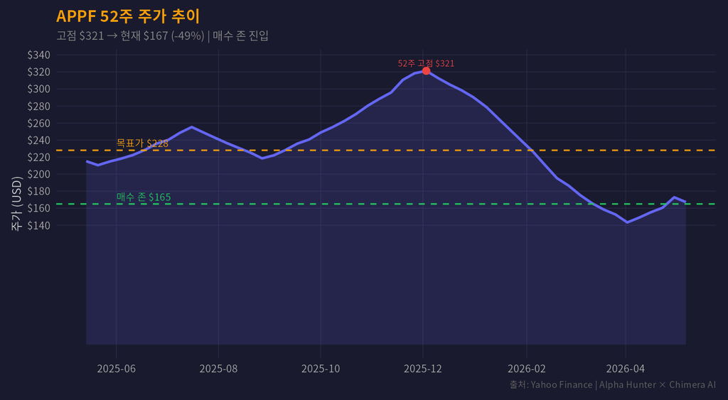

## 1.2 실적 추이 (매출/영업이익)

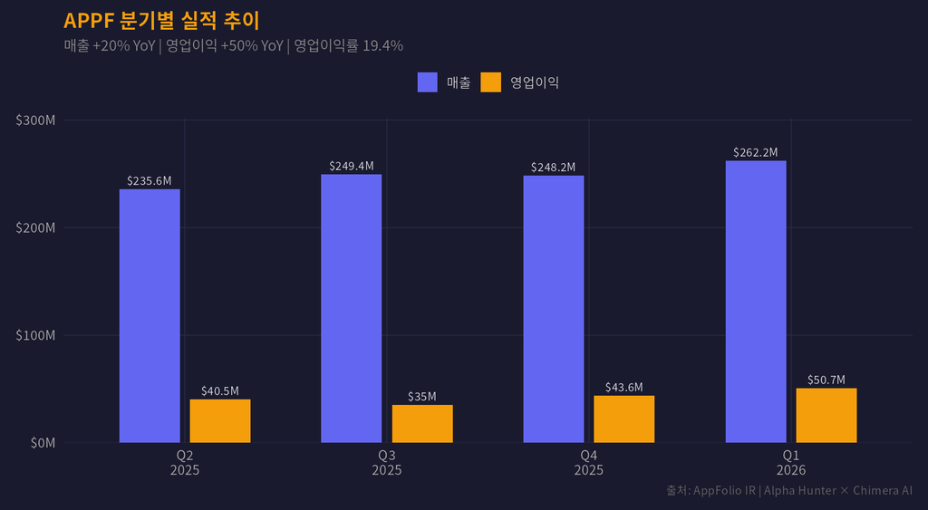

## 1.3 밸류에이션 비교 (동종업종)

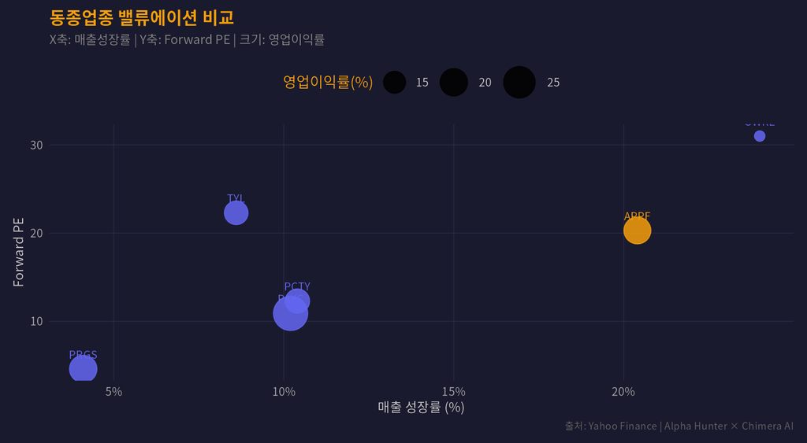

Figure 3: APPF vs 동종 SaaS 밸류에이션 비교 — Forward PE 20.3x로 성장 대비 합리적

## 1.4 워런 버핏 해자 레이더 차트

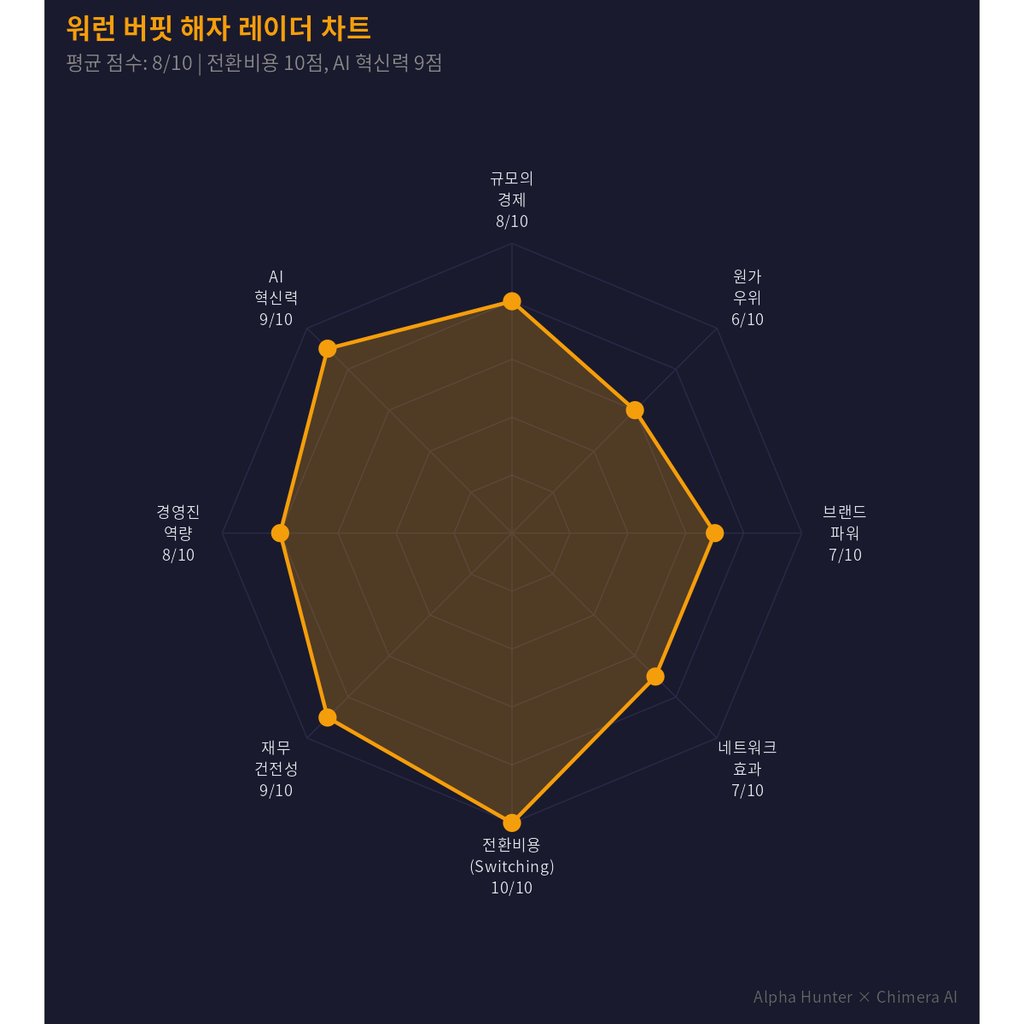

Figure 4: AppFolio 워런 버핏 해자 분석 — 전환비용(10점), AI 혁신력(9점) 최고 수준

## 1.5 피터 린치 스토리 점수

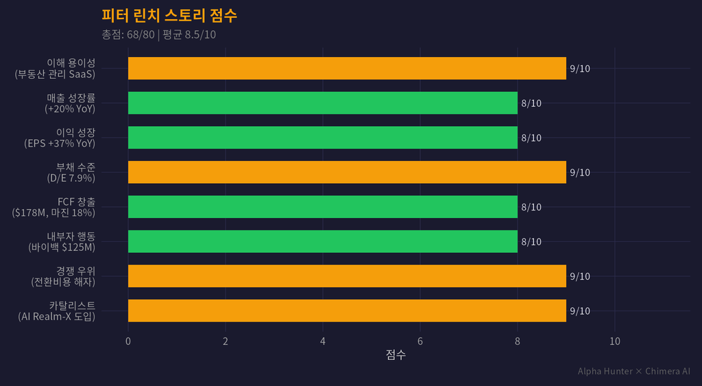

Figure 5: AppFolio 피터 린치 스토리 점수 — 일상에서 보이는 SaaS, 높은 성장성

## 1.6 리스크 팩터 대시보드

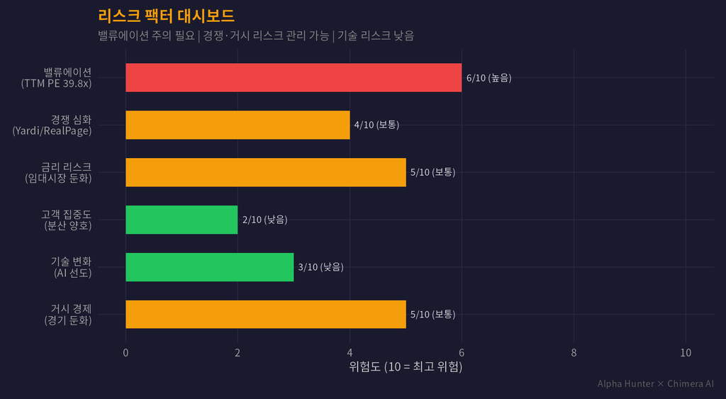

## 1.7 매수/목표/손절가 시나리오

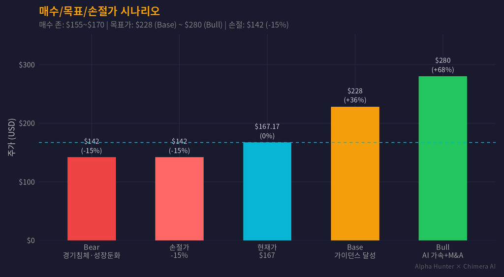

Figure 7: APPF 투자 시나리오 — Bull $280 (+68%), Base $228 (+36%), Bear $142 (-15%)

# 2 핵심 카탈리스트

1. **AI Realm-X 플랫폼 확산** — AI 사용량 7x YoY 증가, Performer 프리미엄 도입률 500% QoQ
2. **2026 가이던스 상향** — 매출 $1.11~$1.125B, 비GAAP 영업이익률 26~28%
3. **자사주매입 지속** — Q1에만 $125M 매입, 유동주식 감소 → EPS 가속
4. **AI 도입 고객 성장률 차별화** — AI 사용자 포트폴리오 +31% 성장 vs 비사용자 +12%
5. **파트너 생태계 확장** — SimpleVoIP, AvidXchange 통합으로 플랫폼 강화

# 3 리스크 요인

- **밸류에이션**: TTM PE 39.8x는 높은 편. 성장 둔화 시 멀티플 압축 가능
- **경쟁**: Yardi, RealPage 등 레거시 경쟁사의 클라우드 전환 가속
- **금리 환경**: 고금리 지속 시 임대시장 둔화 → 신규 유닛 성장 제한
- **기관 매도**: Insight Holdings 등 일부 기관의 보유 축소

# 4 투자 의견

**매수 추천 | 목표가 $228 (+36%)**

**매수 존**: $155 ~ $170 (현재 $167 — 매수 존 내)

**근거**: Forward PE 20.3x에 매출 +20%, 영업이익 +50% 성장. AI 혁신으로 차별적 성장 엔진 보유. 52주 고점 대비 -49% 할인은 과매도. 애널리스트 9명 전원 매수 의견.

**손절가**: $142 (-15%) **목표가 (Base)**: $228 (+36%) — 컨센서스 평균 **목표가 (Bull)**: $280 (+68%) — AI 가속 시나리오

**면책 조항**

이 프로젝트는 가상 투자 시뮬레이션 목적으로 작성되었습니다. 실제 투자 권유가 아니며, 모든 투자 결정은 개인의 판단과 책임 하에 이루어져야 합니다.